# LBB_Reg

Luthfi

2023-10-29

# 1 Introduction : Japanese Hostel

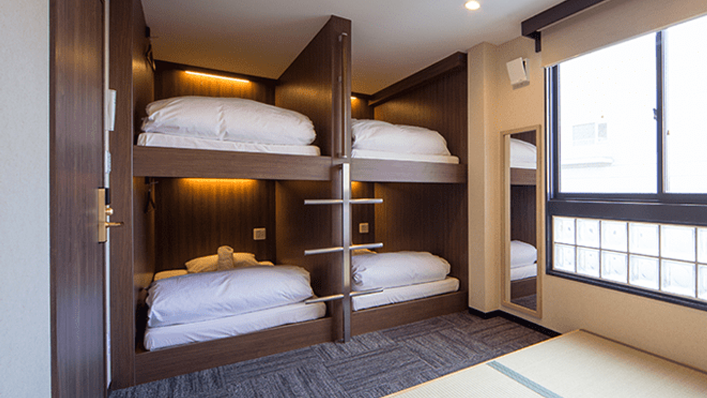

```r
library(knitr)
knitr::include_graphics("Japan Hostel.png")
```

`Img Source`: https://www.momondo.com/rimg/kimg/20/67/261de822f504c173.png?width=1366&height=768&crop=true

`link`: https://www.kaggle.com/datasets/koki25ando/hostel-world-dataset

Data for 300+ Hostels in Japan by Hostel World

Their service is for young and independent travelers seeking a social travel experience. The group focuses on hostels, maintains a leading hostel database with over 16,000 hostels and approximately 20,000 other forms of budget accommodation available globally unlike the other travel agents. Since 2005, it has also been managing customer-generated review database consisting of more than 10 million post-stay reviews.

## 1.1 Notes on Specific Variables

- `hostel.name` = Hostel Name
- `City` = City name where hostel is located in
- `price.from` = Minimum Price for 1 night stay
- `Distance` = Distance from city center (km)
- `summary.score` = Summary score of ratings
- `rating.band` = Rating band
- `atmosphere` = Rating score of atmosphere
- `cleanliness` = Rating score of cleanliness
- `facilities` = Rating score of facilities
- `location.y` = Rating score of location
- `security` = Rating score of security
- `staff` = Rating score of staff
- **`valueformoney`** = Rating score of value for money

## 1.2 Objective

Dependent variable = `valueformoney`

Finding which column is the highest predictor and creating the best model

# 2 Data Preparation

The First step is inserting the csv file into R located in data_input and then installing the necessary plugins including `dplyr`, `lubridate`, `ggally`, etc.

```r
#Read data csv
hostel <- read.csv("hostel_japan_lbb.csv")

library(dplyr)
library(lubridate)
library(GGally)
library(MLmetrics)
library(performance)
library(lmtest)
library(car)
```

Next, we will observe our data set which we exported from the csv

```r
# Opening the dataset
hostel
```

| X | hostel.name | City | price.from | Distance | summary.score | rating.band | atmosphere | cleanliness | facilities | location.y | security | staff | valueformoney |
| --- | --- | --- | --- | --- | --- | --- | --- | --- | --- | --- | --- | --- | --- |
| 1 | "Bike & Bed" CharinCo Hostel | Osaka | 3300 | 2.9km from city centre | 9.2 | Superb | 8.9 | 9.4 | 9.3 | 8.9 | 9.0 | 9.4 | 9.4 |
| 2 | & And Hostel | Fukuoka-City | 2600 | 0.7km from city centre | 9.5 | Superb | 9.4 | 9.7 | 9.5 | 9.7 | 9.2 | 9.7 | 9.5 |
| 3 | &And Hostel Akihabara | Tokyo | 3600 | 7.8km from city centre | 8.7 | Fabulous | 8.0 | 7.0 | 9.0 | 8.0 | 10.0 | 10.0 | 9.0 |
| 4 | &And Hostel Ueno | Tokyo | 2600 | 8.7km from city centre | 7.4 | Very Good | 8.0 | 7.5 | 7.5 | 7.5 | 7.0 | 8.0 | 6.5 |
| 5 | &And Hostel-Asakusa North- | Tokyo | 1500 | 10.5km from city centre | 9.4 | Superb | 9.5 | 9.5 | 9.0 | 9.0 | 9.5 | 10.0 | 9.5 |
| 6 | 1night1980hostel Tokyo | Tokyo | 2100 | 9.4km from city centre | 7.0 | Very Good | 5.5 | 8.0 | 6.0 | 6.0 | 8.5 | 8.5 | 6.5 |
| 7 | 328 Hostel & Lounge | Tokyo | 3300 | 16.5km from city centre | 9.3 | Superb | 8.7 | 9.7 | 9.3 | 9.1 | 9.3 | 9.7 | 8.9 |
| 8 | 36Hostel | Hiroshima | 2000 | 1.6km from city centre | 9.5 | Superb | 8.8 | 9.9 | 9.2 | 9.6 | 9.8 | 9.8 | 9.5 |
| 9 | 3Q House - Asakusa Smile | Tokyo | 2500 | 10.2km from city centre | NA | NA | NA | NA | NA | NA | NA | NA | NA |
| 10 | Ace Inn Shinjuku | Tokyo | 2200 | 3km from city centre | 7.7 | Very Good | 6.7 | 7.2 | 6.8 | 8.5 | 7.8 | 8.5 | 8.1 |

[output cut: 332 more lines]

We will also observe the `str()` to check all the columns

```r
str(hostel)
```

```
## 'data.frame':    342 obs. of  14 variables:
##  $ X            : int  1 2 3 4 5 6 7 8 9 10 ...
##  $ hostel.name  : chr  "\"Bike & Bed\" CharinCo Hostel" "& And Hostel" "&And Hostel Akihabara" "&And Hostel Ueno" ...
##  $ City         : chr  "Osaka" "Fukuoka-City" "Tokyo" "Tokyo" ...
##  $ price.from   : int  3300 2600 3600 2600 1500 2100 3300 2000 2500 2200 ...
##  $ Distance     : chr  "2.9km from city centre" "0.7km from city centre" "7.8km from city centre" "8.7km from city centre" ...
##  $ summary.score: num  9.2 9.5 8.7 7.4 9.4 7 9.3 9.5 NA 7.7 ...
##  $ rating.band  : chr  "Superb" "Superb" "Fabulous" "Very Good" ...
##  $ atmosphere   : num  8.9 9.4 8 8 9.5 5.5 8.7 8.8 NA 6.7 ...
##  $ cleanliness  : num  9.4 9.7 7 7.5 9.5 8 9.7 9.9 NA 7.2 ...
##  $ facilities   : num  9.3 9.5 9 7.5 9 6 9.3 9.2 NA 6.8 ...
##  $ location.y   : num  8.9 9.7 8 7.5 9 6 9.1 9.6 NA 8.5 ...
##  $ security     : num  9 9.2 10 7 9.5 8.5 9.3 9.8 NA 7.8 ...
##  $ staff        : num  9.4 9.7 10 8 10 8.5 9.7 9.8 NA 8.5 ...
##  $ valueformoney: num  9.4 9.5 9 6.5 9.5 6.5 8.9 9.5 NA 8.1 ...
```

After checking the `str()`, we will delete all the rows that contains NA valued data within it to prevent unnecessary error during modeling.

```r
# Deleting rows with NA value
hostel <- na.omit(hostel)
```

Next, we will remove the columns that have too many unique variables, as they do not contribute to our modeling process.

```r
# Deleting unnecessary columns (which has too many unique variables)
hostel <- hostel %>%
  select(-c(X, hostel.name))
```

```r
# Checking the uniques of rating.band
unique(hostel$rating.band)
```

```
## [1] "Superb"    "Fabulous"  "Very Good" "Rating"    "Good"
```

Considering that `Rating` seems unrelated to the other four unique variables, we will proceed to remove it, as it may be an erroneous entry. Furthermore, we plan to modify the column type from character to factor.

```r
# Filtering out "Rating" from hostel$rating.band
hostel <- hostel %>%
  filter(rating.band != "Rating") %>%
  mutate(rating.band = as.factor(rating.band))
```

Afterward, we will remove the words from `Distance` column and turn it into numerical.

```r
# Cleaning distance column
hostel$Distance <- as.numeric(gsub("km from city centre", "", hostel$Distance))
```

```r
# Checking the uniques of the city column
unique(hostel$City)
```

```
## [1] "Osaka"        "Fukuoka-City" "Tokyo"        "Hiroshima"    "Kyoto"
```

Turning `hostel$City` into factors as there are only 5 uniques.

```r
# Mutating city into factor
hostel <- hostel %>%
  mutate(City = as.factor(City))
```

# 3 Data Exploration

According to the plot below, `summary.score` exhibits the highest correlation with `valueformoney`, with a correlation coefficient of 0.8. This is followed by `facilities`, which has a correlation coefficient of 0.7. While `Distance` and `price.from` has the lowest correlation with the score of 0.1 and -0.2.

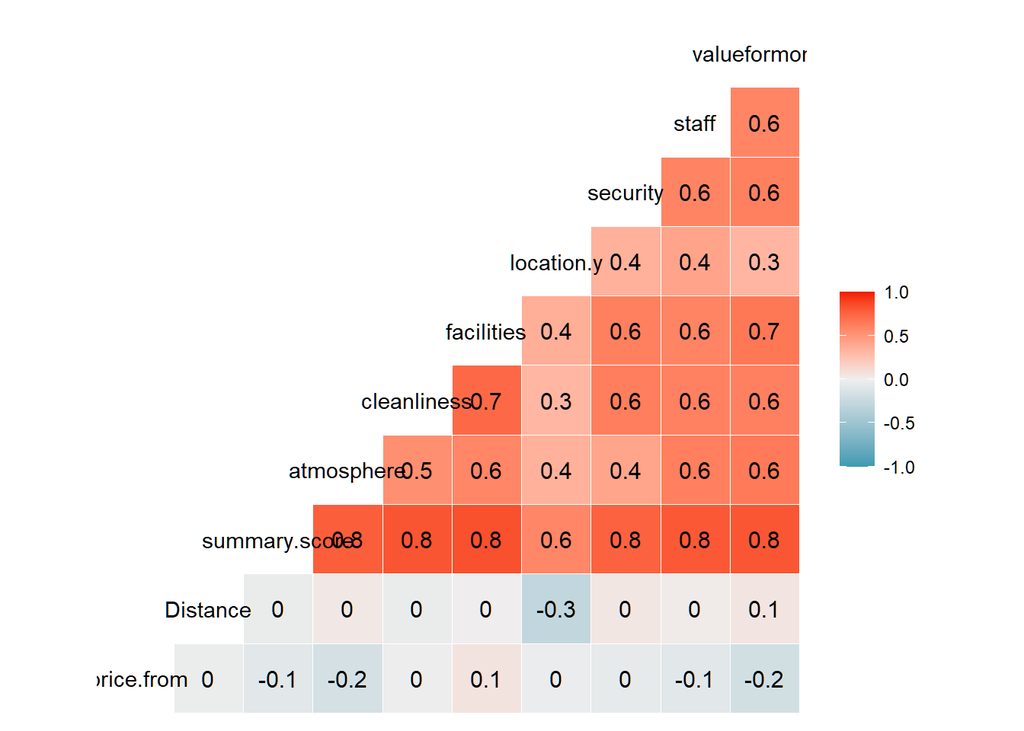

```r
#By using ggcorr, we will know which columns correlates more with our dependent variable, the closer it is to -1 / 1,  the higher the correlation.
ggcorr(hostel, label=T)
```

## 3.1 First Model (All Predictors)

The first model we will create is by using all of the available predictors.

```r
model_1 <- lm(formula = valueformoney ~ . , data = hostel)

summary(model_1)
```

```
##
## Call:
## lm(formula = valueformoney ~ ., data = hostel)
##
## Residuals:
##      Min       1Q   Median       3Q      Max
## -0.40711 -0.13780  0.00058  0.14003  0.37675
##
## Coefficients:
##                        Estimate Std. Error t value Pr(>|t|)
## (Intercept)           5.344e-01  3.521e-01   1.518    0.130
## CityHiroshima        -3.324e-02  6.697e-02  -0.496    0.620
## CityKyoto            -5.297e-03  4.961e-02  -0.107    0.915
## CityOsaka            -2.198e-02  4.953e-02  -0.444    0.657
## CityTokyo            -8.568e-03  5.058e-02  -0.169    0.866
## price.from           -1.589e-07  1.384e-07  -1.148    0.252
## Distance             -3.402e-03  2.756e-03  -1.234    0.218
## summary.score         6.051e+00  1.279e-01  47.314   <2e-16 ***
## rating.bandGood      -8.331e-02  1.027e-01  -0.811    0.418
## rating.bandSuperb     4.134e-02  3.761e-02   1.099    0.273
## rating.bandVery Good  6.287e-02  6.105e-02   1.030    0.304
## atmosphere           -8.143e-01  2.515e-02 -32.381   <2e-16 ***
## cleanliness          -8.877e-01  2.607e-02 -34.051   <2e-16 ***
## facilities           -8.417e-01  2.774e-02 -30.345   <2e-16 ***
## location.y           -8.832e-01  2.207e-02 -40.018   <2e-16 ***
## security             -8.245e-01  2.796e-02 -29.490   <2e-16 ***
## staff                -8.560e-01  2.777e-02 -30.829   <2e-16 ***
## ---
## Signif. codes:  0 '***' 0.001 '**' 0.01 '*' 0.05 '.' 0.1 ' ' 1
##
## Residual standard error: 0.182 on 302 degrees of freedom
## Multiple R-squared:  0.9576, Adjusted R-squared:  0.9553
## F-statistic: 426.1 on 16 and 302 DF,  p-value: < 2.2e-16
```

Model Interpretation: - 95% variance from target(valueformoney) could be explained by the predictor - summary.score,atmosphere,cleanliness,facilities,location.y,security, and staff are the most significant predictors

## 3.2 Second Model

```r
model_2 <- lm(formula = valueformoney ~ summary.score  , data = hostel)

summary(model_2)
```

```
##
## Call:
## lm(formula = valueformoney ~ summary.score, data = hostel)
##
## Residuals:
##      Min       1Q   Median       3Q      Max
## -2.31163 -0.23957 -0.02819  0.24147  2.19595
##
## Coefficients:
##               Estimate Std. Error t value Pr(>|t|)
## (Intercept)    0.39608    0.33928   1.167    0.244
## summary.score  0.96207    0.03807  25.269   <2e-16 ***
## ---
## Signif. codes:  0 '***' 0.001 '**' 0.01 '*' 0.05 '.' 0.1 ' ' 1
##
## Residual standard error: 0.4967 on 317 degrees of freedom
## Multiple R-squared:  0.6682, Adjusted R-squared:  0.6672
## F-statistic: 638.5 on 1 and 317 DF,  p-value: < 2.2e-16
```

Model Interpretation: - A decrease of R-squared to 66% by using only a single predictor

## 3.3 Third Model

The third model is using all the high correlation predictors from the first model

```r
model_3 <- lm(formula = valueformoney ~  summary.score + atmosphere + cleanliness + facilities + location.y + security + staff  , data = hostel)

summary(model_3)
```

```
##
## Call:
## lm(formula = valueformoney ~ summary.score + atmosphere + cleanliness +
##     facilities + location.y + security + staff, data = hostel)
##
## Residuals:
##      Min       1Q   Median       3Q      Max
## -0.40983 -0.13166 -0.00002  0.13739  0.41642
##
## Coefficients:
##               Estimate Std. Error t value Pr(>|t|)
## (Intercept)    0.27984    0.14045   1.992   0.0472 *
## summary.score  6.04296    0.12004  50.342   <2e-16 ***
## atmosphere    -0.80753    0.02438 -33.119   <2e-16 ***
## cleanliness   -0.88074    0.02525 -34.884   <2e-16 ***
## facilities    -0.84252    0.02609 -32.289   <2e-16 ***
## location.y    -0.87365    0.02069 -42.229   <2e-16 ***
## security      -0.81664    0.02732 -29.892   <2e-16 ***
## staff         -0.85035    0.02718 -31.283   <2e-16 ***
## ---
## Signif. codes:  0 '***' 0.001 '**' 0.01 '*' 0.05 '.' 0.1 ' ' 1
##
## Residual standard error: 0.1821 on 311 degrees of freedom
## Multiple R-squared:  0.9563, Adjusted R-squared:  0.9553
## F-statistic: 971.3 on 7 and 311 DF,  p-value: < 2.2e-16
```

Model Interpretation: - Model has the same R-squared as the first model by using only the significant ones

# 4 Prediction

To compare the models we created and the original value of our dependable variable, we will need to create a new dataset called `hostel_pred`.

```r
hostel_pred <- data.frame(ori_value = hostel$valueformoney) #Creating dataframe
```

Next, we will insert the model predictions into the dataset so we could observe it easily by using the command head().

```r
hostel_pred$model_1 <- predict(model_1, hostel)
hostel_pred$model_2<- predict(model_2, hostel)
hostel_pred$model_3 <- predict(model_3, hostel)

head(hostel_pred)
```

|  | ori_value | model_1 | model_2 | model_3 |
| --- | --- | --- | --- | --- |
| 1 | 9.4 | 9.468384 | 9.247157 | 9.454981 |
| 2 | 9.5 | 9.343267 | 9.535779 | 9.314019 |
| 3 | 9.0 | 8.970663 | 8.766120 | 8.986260 |
| 4 | 6.5 | 6.609838 | 7.515423 | 6.541279 |
| 5 | 9.5 | 9.327466 | 9.439571 | 9.337841 |
| 6 | 6.5 | 6.701537 | 7.130594 | 6.626679 |

## 4.1 Mean Absolute Error

Mean Absolute Error (MAE) is a simple metric used to measure the accuracy of predictive models in regression. It calculates the average absolute difference between predicted and actual values. MAE is easy to understand, less sensitive to outliers than some other metrics, and minimization during model training results in predictions that are as close as possible to actual values.

```r
#Comparing the MAE's of the three models
MAE(y_pred = hostel_pred$model_1,
    y_true = hostel_pred$ori_value)
```

```
## [1] 0.1489212
```

```r
MAE(y_pred = hostel_pred$model_2,
    y_true = hostel_pred$ori_value)
```

```
## [1] 0.3311511
```

```r
MAE(y_pred = hostel_pred$model_3,
    y_true = hostel_pred$ori_value)
```

```
## [1] 0.1491836
```

## 4.2 Mean Squared Error

Mean Squared Error (MSE) is a commonly used metric in regression analysis to assess predictive model accuracy. It quantifies the average of the squared differences between predicted values and actual values in a dataset. MSE provides a more comprehensive assessment of errors by squaring them, making it sensitive to large errors. During model training, minimizing MSE results in predictions that aim to minimize the overall squared error. However, the squared terms may obscure the understanding of the metric’s practical meaning, and it can be heavily influenced by outliers.

```r
#Comparing the MSE's of the three models
MSE(y_pred = hostel_pred$model_1,
    y_true = hostel_pred$ori_value)
```

```
## [1] 0.03134586
```

```r
MSE(y_pred = hostel_pred$model_2,
    y_true = hostel_pred$ori_value)
```

```
## [1] 0.2451581
```

```r
MSE(y_pred = hostel_pred$model_3,
    y_true = hostel_pred$ori_value)
```

```
## [1] 0.03232151
```

Model Interpretation: - Model 1 has the lowest MSE score of 0.03134586 followed closely by Model 3

## 4.3 Root Mean Squared Error

Root Mean Squared Error (RMSE) is a widely used metric in regression analysis to gauge the accuracy of predictive models. It’s derived from the Mean Squared Error (MSE) but has a square root applied, making it more interpretable as it’s in the same unit as the target variable. RMSE penalizes large errors and offers a holistic view of prediction accuracy. While it’s more intuitive, it can still be influenced by outliers, and the square root may complicate the understanding of the metric’s practical significance.

```r
#Comparing the RMSE's of the three models
RMSE(y_pred = hostel_pred$model_1,
    y_true = hostel_pred$ori_value)
```

```
## [1] 0.1770476
```

```r
RMSE(y_pred = hostel_pred$model_2,
    y_true = hostel_pred$ori_value)
```

```
## [1] 0.4951344
```

```r
RMSE(y_pred = hostel_pred$model_3,
    y_true = hostel_pred$ori_value)
```

```
## [1] 0.1797818
```

Model Interpretation: - Model 1 has the lowest RMSE score of 0.1770476 followed closely by Model 3

## 4.4 Prediction Summary

📌 In summary, from all the three models created, `Model 1` is the best because of the following reasons:

- Highest R-Squared value (0.9553)
- Lowest MAE (0.1489212)
- Lowest MSE (0.03134586)
- Lowest RMSE (0.1770476)

Following closely is `Model 3` with the following points:

- R-Squared value (0.9553) **same R-squared value as Model 1**
- MAE (0.1491836)
- MSE (0.03232151)
- RMSE (0.1797818)

`Model 2` has the worst prediction of all three models by using only a single predictor which has the highest correlation

- R-Squared value (0.6682)
- MAE (0.3311511)
- MSE (0.2451581)
- RMSE (0.4951344)

Therefore, going forward, we will exclusively use `Model 1` for evaluation.

# 5 Model Evaluation

## 5.1 Normality

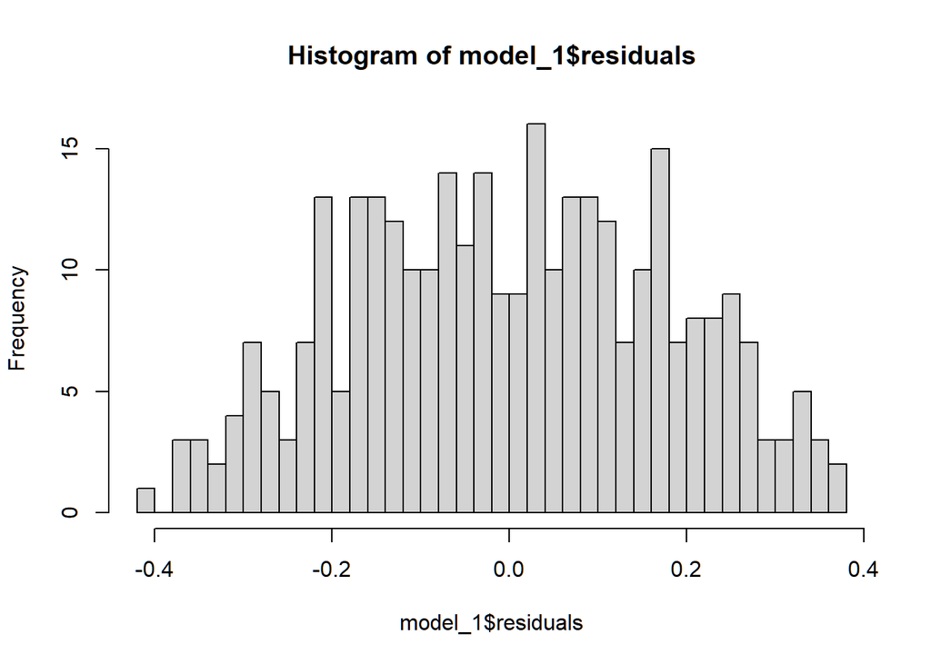

```r
hist(model_1$residuals, breaks = 40)
```

```r
shapiro.test(model_1$residuals)
```

```
##
##  Shapiro-Wilk normality test
##
## data:  model_1$residuals
## W = 0.98565, p-value = 0.002902
```

P-value is below 0.005, that means the residuals aren’t normally distributed.

## 5.2 Heteroscedasticity

```r
# Creating the data frame
linear <- data.frame(residual = model_1$residuals, fitted = model_1$fitted.values)
```

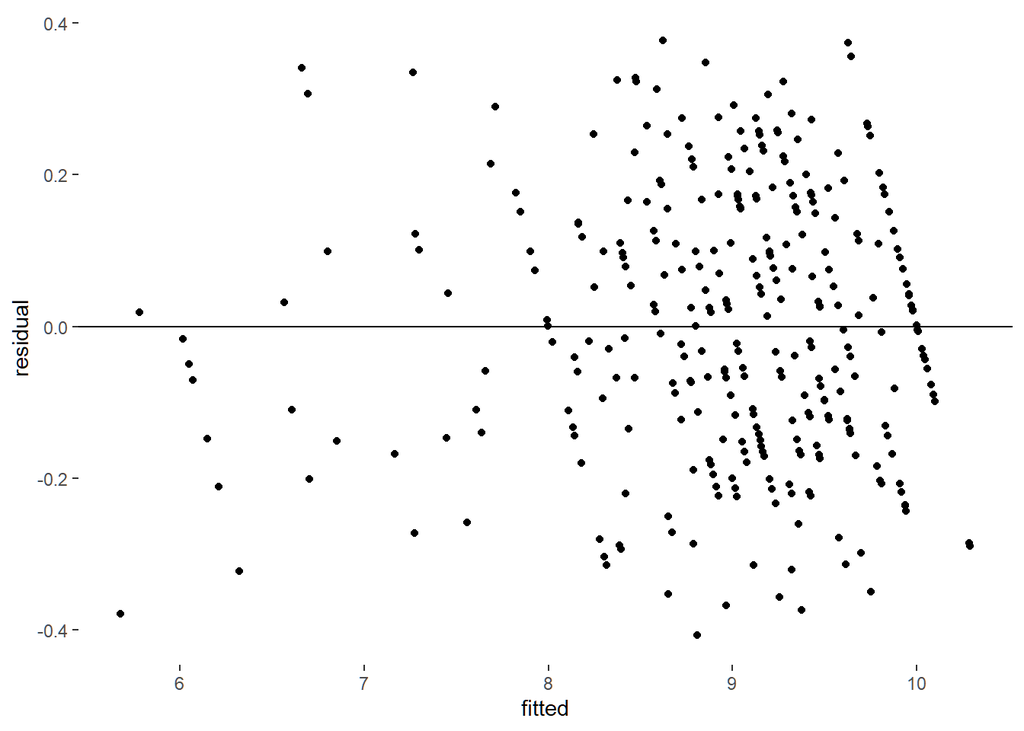

```r
# Plotting the data frame
linear %>%
  ggplot(aes(fitted, residual)) +
  geom_point() + geom_hline(aes(yintercept = 0)) +
    theme(panel.grid = element_blank(), panel.background = element_blank())
```

```r
bptest(model_1)
```

```
##
##  studentized Breusch-Pagan test
##
## data:  model_1
## BP = 11.524, df = 16, p-value = 0.7761
```

P-value is > 0.05, which means that heterocesdasticity is not present

## 5.3 Autocorrelation

```r
set.seed(501)
durbinWatsonTest(model_1)
```

```
##  lag Autocorrelation D-W Statistic p-value
##    1     -0.04915836      2.097224   0.342
##  Alternative hypothesis: rho != 0
```

P-value is > 0.005, which means that autocorrelation is not present

## 5.4 Linearity

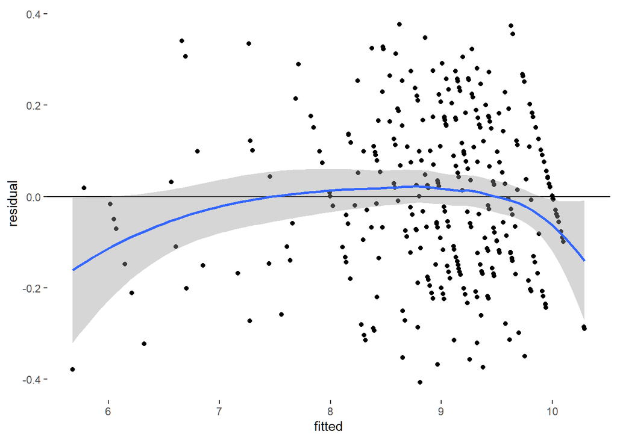

```r
# Plotting the data frame
linear %>%
  ggplot(aes(fitted, residual)) +
  geom_point() +
  geom_hline(aes(yintercept = 0)) +
    geom_smooth() +
  theme(panel.grid = element_blank(), panel.background = element_blank())
```

There is a curved pattern on the ggplot model, which means the model isn’t fully linear.

## 5.5 Variance Inflation Factor

```r
vif(model_1)
```

```
##                    GVIF Df GVIF^(1/(2*Df))
## City           1.609416  4        1.061289
## price.from     1.151456  1        1.073059
## Distance       1.540604  1        1.241211
## summary.score 84.075852  1        9.169289
## rating.band    9.110442  3        1.445184
## atmosphere     8.115346  1        2.848745
## cleanliness    6.376232  1        2.525120
## facilities     7.419033  1        2.723790
## location.y     4.574148  1        2.138726
## security       5.565032  1        2.359032
## staff          4.250681  1        2.061718
```

# 6 Conclusion

In conclusion, `model_1` demonstrates **strong predictive performance**, evidenced by the **highest R-Squared** value of 0.9553, indicating a substantial explanation of data variation. The model exhibits impressive precision with the **lowest Mean Absolute Error (MAE), Mean Squared Error (MSE), and Root Mean Squared Error (RMSE), reflecting minimal prediction errors**. *However*, caution is warranted as the **residuals deviate from a normal distribution (p-value = 0.002902)**, implying a departure from a typical pattern. Additionally, the presence of a curved pattern in the ggplot model suggests potential **non-linearity**. Multicollinearity concerns, especially with the “summary.score” variable, are highlighted by high GVIF. In practical terms, the model offers **robust predictions** but *requires consideration of non-normality, potential non-linearity, and multicollinearity* in its interpretation and application.